# NLP_Project_FullCode

#### Date vs Price (Open, High, Low, Close)

```python
stock_daily = stock.groupby('Date').agg(
    {
        'Open': 'mean',
        'High': 'mean',
        'Low': 'mean',
        'Close': 'mean',
        'Volume': 'mean',
    }
).reset_index()  # Group by the 'Date' column

stock_daily.set_index('Date', inplace=True)
stock_daily.head()
```

| Date | Open | High | Low | Close | Volume |
| --- | --- | --- | --- | --- | --- |
| 2019-01-02 | 41.740002 | 42.244999 | 41.482498 | 40.246914 | 130672400.0 |
| 2019-01-03 | 43.570000 | 43.787498 | 43.222500 | 42.470604 | 103544800.0 |
| 2019-01-04 | 47.910000 | 47.919998 | 47.095001 | 46.419842 | 111448000.0 |
| 2019-01-07 | 50.792500 | 51.122501 | 50.162498 | 49.110790 | 109012000.0 |
| 2019-01-08 | 53.474998 | 54.507500 | 51.685001 | 50.787209 | 216071600.0 |

Observations:

After averaging stock metrics per date,it prepares our dataset for time-series plots or date-aligned features

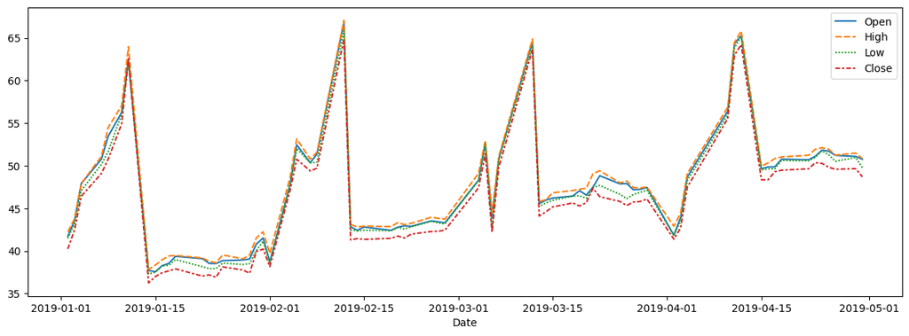

```python
plt.figure(figsize=(15,5))
sns.lineplot(stock_daily.drop("Volume", axis=1));  # Plot all variables except Volume
```

Observations:

#### Volume vs Close Price

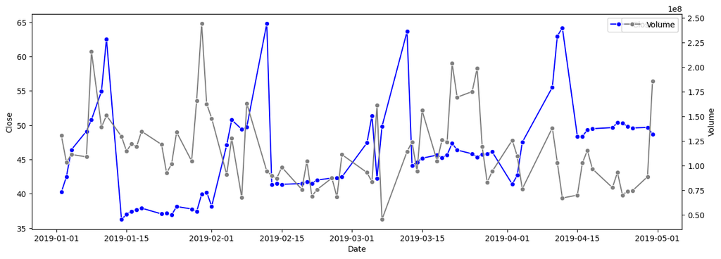

```python
# Create a figure and axis
fig, ax1 = plt.subplots(figsize=(15,5))

# Lineplot on primary y-axis
sns.lineplot(data=stock_daily.reset_index(), x='Date', y='Close', ax=ax1, color='blue', marker='o', label='Close Price')

# Create a secondary y-axis
ax2 = ax1.twinx()

# Lineplot on secondary y-axis
sns.lineplot(data=stock_daily.reset_index(), x='Date', y='Volume', ax=ax2, color='gray', marker='o', label='Volume')

ax1.legend(bbox_to_anchor=(1,1));
```

Observations:

There are clear volume spikes on specific dates.

These spikes are not frequent.

In some areas, volume increases without a significant price move, which hints at speculative trading.

In a few places, a price drop or rise follows a volume surge, but not consistently — suggesting no strong or reliable correlation between Volume and Close price in this dataset.

Without factoring in news sentiment, volume alone doesn't explain price behavior.

## **Data Preprocessing**

```python
stock["Date"].describe() #Complete the code to print the statistical summary of the 'Date' column
```

|  | Date |
| --- | --- |
| count | 349 |
| mean | 2019-02-16 16:05:30.085959936 |
| min | 2019-01-02 00:00:00 |
| 25% | 2019-01-14 00:00:00 |
| 50% | 2019-02-05 00:00:00 |
| 75% | 2019-03-22 00:00:00 |
| max | 2019-04-30 00:00:00 |

**dtype:** object

### Train-test-validation Split

```python
X_train = stock[(stock['Date'] < '2019-04-01')].reset_index()
X_val = stock[(stock['Date'] >= '2019-04-01') & (stock['Date'] < '2019-04-16')].reset_index()
X_test = stock[stock['Date'] >= '2019-04-16'].reset_index()
```

Observations: Lets train data using data upto March 31st 2019. And run model against the validation data from April 1 to April 15th 2019. And test with data from April 16th onwards.

```python
# Complete the code to pick the 'Label' column as the target variable
y_train = X_train["Label"].copy()
y_val = X_val["Label"].copy()
y_test = X_test["Label"].copy()
```

Observations: Let's isoloate the target variable from training, test and validation data.

```python
#Complete the code to print the shape of X_train,X_val,X_test,y_train,y_val and y_test
print("Train data shape",X_train.shape)
print("Validation data shape",X_val.shape)
print("Test data shape ",X_test.shape)

print("Train label shape",y_train.shape)
print("Validation label shape",y_val.shape)
print("Test label shape ",y_test.shape)
```

```
Train data shape (286, 10)
Validation data shape (21, 10)
Test data shape  (42, 10)
Train label shape (286,)
Validation label shape (21,)
Test label shape  (42,)
```

Observations:

A solid training set for fitting your model.

A test set for final unbiased evaluation.

A validation set for tuning hyperparameters or monitoring overfitting (though slightly small).

## **Word Embeddings**

### Word2Vec

```python
# Creating a list of all words in our data
words_list = [item.split(" ") for item in stock['News'].values]
```

Observations: The result is a list of lists, where each inner list contains individual words from a single news entry.

```python
# Creating an instance of Word2Vec
vec_size = 300
model_W2V = Word2Vec(words_list, vector_size = vec_size, min_count = 1, window=5, workers = 6)
```

Observations:

We are using news headlines to train the embeddings, it means vector space is contextually tuned to financial language.

Each word will be represented as a 300-dimensional vector

Looks at 5 words before and after the target word to get context.

```python
# Checking the size of the vocabulary
print("Length of the vocabulary is", len(list(model_W2V.wv.key_to_index)))
```

```
Length of the vocabulary is 4682
```

Observations:

With only 349 news entries, a vocabulary of 4,682 unique words is quite large.Therefore text is highly diverse.

Let's check out a few word embeddings obtained using the model.

```python
# Checking the word embedding of a random word
word = "stock"
model_W2V.wv[word]
```

```
array([-2.02370016e-03,  3.85143384e-02,  7.38847163e-03,  1.15291467e-02,
        2.00947933e-03, -5.64098991e-02,  2.88168229e-02,  8.78903419e-02,
        3.51623236e-03, -2.24954356e-02,  4.80430946e-03, -2.08250582e-02,
       -4.17812308e-03,  1.41794533e-02, -2.62250751e-02, -2.65340116e-02,
        2.17638779e-02, -4.45793802e-03,  5.90414228e-03, -2.59113293e-02,
       -2.28653476e-02,  7.17722392e-03,  2.86644120e-02,  1.45488195e-02,
        2.37827003e-02,  2.16769011e-04, -3.53674144e-02,  8.24647956e-03,
       -2.75574941e-02, -4.30375747e-02,  1.14744985e-02, -2.63173841e-02,
        3.62951984e-03, -9.64764412e-03, -1.46250066e-03,  2.41914615e-02,
        1.32997306e-02, -3.46401036e-02, -3.30136716e-03, -1.33008696e-02,
       -1.79803912e-02,  3.66124325e-03,  1.24798482e-03, -1.89772677e-02,
        1.90459695e-02,  3.81468870e-02,  7.93073792e-03,  1.89931095e-02,
       -8.83688161e-04,  2.24095676e-02,  1.07543403e-02, -1.01133082e-02,
       -2.00914145e-02,  1.42094390e-02, -7.14597665e-03,  2.59550977e-02,
        1.81324463e-02,  2.65261997e-03,  6.70872582e-03,  2.26455019e-03,
       -1.32609634e-02, -9.58424248e-03, -5.87600225e-05,  1.10583669e-02,
       -3.83577892e-04,  1.58287697e-02,  6.03994727e-03,  1.19034443e-02,
       -2.59206183e-02, -1.00583630e-02, -5.93438745e-04,  2.29454897e-02,
        3.49893421e-02, -2.00777352e-02,  9.38899163e-03,  1.51570356e-02,
       -3.22390832e-02,  2.79513886e-03, -1.47075858e-02,  2.54175682e-02,
       -1.45046217e-02, -2.60928292e-02,  5.42339589e-03,  6.22998551e-02,
        6.63138926e-03, -2.38971552e-03, -1.19596329e-02,  6.08431641e-03,
        3.84879857e-02,  1.53537197e-02,  3.10060605e-02, -1.47249755e-02,
        1.97192077e-02, -9.04652334e-05,  3.72045264e-02,  3.41158248e-02,
        2.90387049e-02, -1.49073955e-02, -1.40394904e-02,  2.25287415e-02,
        4.84373374e-03,  3.37902806e-03,  2.86013465e-02,  1.44332983e-02,
        5.19103091e-03, -1.88415963e-02, -1.35437334e-02,  1.90909859e-02,
       -1.91446021e-02,  5.84838679e-03, -4.88654859e-02, -2.65293997e-02,
       -2.09432142e-03,  2.52165608e-02,  1.63117368e-02,  2.27713455e-02,
       -4.67295386e-03, -2.83080176e-03,  5.24494797e-02, -4.56885733e-02,
        9.77566186e-03,  2.44479682e-02,  2.58740634e-02, -4.23302269e-03,
       -2.07164623e-02,  1.98443308e-02,  1.47945639e-02, -3.74232829e-02,
       -9.80343786e-04,  1.72036402e-02,  1.37910610e-02,  4.17229980e-02,
        1.96382087e-02, -3.92887779e-02,  9.40188672e-03,  2.33070869e-02,
       -1.08923726e-02, -3.11206467e-02, -4.12568599e-02, -4.27741371e-02,
        1.49169341e-02, -3.87324318e-02, -1.44671425e-02,  1.65003873e-02,
        1.46092027e-02, -1.44975837e-02, -5.94140291e-02, -9.48371459e-03,
        2.92368010e-02, -1.98204275e-02,  7.76614109e-03, -4.90351729e-02,
       -1.53922606e-02, -1.49823148e-02,  9.64776799e-03,  2.70108432e-02,
       -3.83031256e-02, -1.87026951e-02, -1.62569387e-03,  3.13762873e-02,
```

[output cut: 21 more lines]

```
        7.05406244e-04, -4.46722843e-02, -9.67185758e-03,  1.36953406e-02,
        3.39121767e-03,  2.23920196e-02,  1.10871177e-02,  2.68111820e-03,
        2.78904196e-02, -4.00367146e-03, -3.39278840e-02, -2.04164088e-02,
        5.20696044e-02,  1.30199296e-02, -5.05266227e-02, -2.95350775e-02,
        2.24199090e-02,  1.88536830e-02,  1.77051444e-02, -5.74403554e-02,
       -3.97968851e-02,  4.97319689e-03,  1.64199471e-02,  1.99773945e-02,
       -3.22963372e-02,  1.19243981e-02, -2.01818515e-02,  8.43999675e-04,
       -4.22420958e-03, -7.17755593e-03,  3.02492771e-02,  1.69387776e-02,
        1.77205540e-02,  1.38274552e-02, -3.47679481e-02, -5.96952718e-03,
        1.45195425e-02, -2.88863946e-03, -1.75575987e-02,  1.88626368e-02,
       -2.56911619e-03, -8.58032261e-04, -4.64688465e-02,  2.47844663e-02,
        4.50863643e-03,  3.98884378e-02,  1.48933362e-02,  4.97774296e-02,
        3.46692540e-02,  2.09749257e-03,  4.47769687e-02,  5.48829548e-02,
        6.29755855e-03, -2.47722007e-02,  3.19137312e-02, -1.99621152e-02],
      dtype=float32)
```

Observations:

Now, we are getting a word embedding vector for a specific word using your trained Word2Vec model.

This vector represents the semantic meaning of the word "stock" .Each number in the array is a dimension in the learned embedding space.

```python
# Checking the word embedding of a random word
word = "economy"
model_W2V.wv[word]
```

```
array([-8.6877943e-04,  5.5111004e-03,  3.1234843e-03,  1.9725766e-03,
       -1.0286444e-03, -1.1523341e-02,  6.8392050e-03,  1.6077708e-02,
       -2.0085778e-03, -2.3545995e-03, -2.6055875e-03, -3.5587696e-03,
        8.4835966e-04, -3.4791735e-04, -4.4354405e-03, -1.8257098e-03,
        7.1369959e-03,  1.8228008e-03,  3.6506944e-03, -2.9859466e-03,
       -5.8936933e-03,  2.6904689e-03,  3.9673694e-03, -8.2602567e-04,
        1.2995644e-03, -1.2910553e-03, -7.2880471e-03,  2.2825177e-03,
       -6.5748282e-03, -1.0171713e-02, -1.7078748e-03, -6.5229172e-03,
        2.7615535e-03, -2.8482943e-03, -2.6545017e-03,  6.1369566e-03,
        2.9023468e-05, -5.5956258e-03, -1.9870940e-04, -3.1498112e-03,
       -5.5275564e-03,  7.9306000e-04,  1.6425314e-03, -3.7326270e-03,
        3.8806575e-03,  4.0099472e-03, -7.1850308e-04,  1.4117225e-03,
       -1.9630163e-04,  9.7942282e-04,  4.5337928e-03, -4.3110494e-03,
       -4.0972866e-03,  5.5956724e-04, -2.9442455e-03,  6.9537484e-03,
        1.2918224e-03,  3.7239769e-03,  1.2372801e-03, -1.2438655e-03,
       -5.4985085e-03,  2.0703797e-03,  1.6731581e-03, -9.5998711e-04,
       -3.6942697e-04,  2.2490190e-03,  1.9247471e-03,  2.2153379e-03,
       -5.8220564e-03, -2.1577000e-03, -1.9286217e-03,  5.9648682e-03,
        7.1366001e-03, -1.2127272e-03,  4.3389271e-03, -1.3387295e-03,
       -3.3358363e-03,  5.7192618e-04, -3.9373102e-04,  5.7296236e-03,
       -1.0210776e-03, -1.0709617e-03, -2.9002421e-04,  1.0644648e-02,
        3.0951640e-03, -1.2751345e-03, -3.5143355e-03,  1.3207578e-03,
        8.9779943e-03, -2.8577787e-04,  2.7915332e-03, -5.1037432e-03,
        2.2205317e-03,  5.1190864e-06,  4.0356140e-03,  4.8252675e-03,
        3.2133411e-03, -2.0716034e-03, -5.2870288e-03,  9.5594500e-04,
        1.5487644e-03, -2.3288892e-03,  7.3226341e-03,  4.5133703e-03,
        1.6062388e-03, -5.2143475e-03, -2.1692889e-03,  4.6883696e-03,
       -3.6568732e-03,  2.4207907e-03, -8.3082672e-03, -2.4435406e-03,
       -1.5103437e-03,  5.5681444e-03,  4.9501439e-03,  6.4602972e-04,
       -2.5205181e-03,  2.7473655e-03,  8.5757310e-03, -9.3031572e-03,
        1.2144811e-03,  2.2114308e-03,  4.0966757e-03,  2.8600701e-04,
       -2.5704412e-03,  2.5278712e-03,  2.4172633e-03, -3.4288352e-03,
        2.0280904e-03,  1.8974062e-03, -1.1207573e-03,  9.0576271e-03,
        3.4168190e-03, -5.8506909e-03,  2.9124315e-03,  5.3634760e-03,
       -1.4440703e-03, -2.9492246e-03, -6.8697925e-03, -1.0114933e-02,
        1.3560512e-03, -5.8401725e-03, -3.0529783e-03,  5.0153369e-03,
        1.1827443e-04,  9.4005745e-04, -1.0841720e-02, -5.7719095e-04,
        6.2819226e-03, -1.8897885e-04,  5.4145075e-04, -9.5243286e-03,
        3.4421205e-04, -2.3903900e-03, -2.1635432e-04,  4.7022891e-03,
       -9.6979076e-03, -2.7871397e-03,  3.6319576e-03,  2.1450315e-03,
```

[output cut: 21 more lines]

```
       -1.3859775e-03, -7.9595065e-03, -1.9017389e-03,  1.8910174e-03,
        2.8099702e-03,  1.6452414e-04, -3.9207513e-04, -3.5164423e-05,
        5.2971132e-03, -1.2920285e-04, -5.3078081e-03, -4.7863061e-03,
        6.8559395e-03,  4.3372279e-03, -1.0577702e-02, -2.7018059e-03,
        1.9179860e-03,  3.1575090e-03,  4.5187605e-04, -6.2088030e-03,
       -5.3681750e-03,  2.8660258e-03,  3.9195600e-03,  3.0380145e-03,
       -2.0083869e-03,  3.2118238e-03, -5.6123245e-03,  3.6715283e-03,
       -1.0871743e-03,  5.5917521e-04,  2.2596852e-03,  4.2654024e-03,
        4.2723427e-03,  4.8454939e-03, -2.5330544e-03, -3.9823661e-03,
        4.5803837e-03, -7.0822971e-06, -2.8075743e-03,  4.0284093e-03,
       -8.7813579e-04, -1.8713846e-03, -6.6320118e-03,  3.1595784e-03,
        6.1246625e-04,  9.0274690e-03,  1.4528614e-03,  6.2677590e-03,
        3.0564803e-03, -1.8720072e-03,  7.6385629e-03,  9.4839931e-03,
        3.2013867e-03, -6.7807804e-03,  2.1265058e-03, -1.1234141e-03],
      dtype=float32)
```

Observations:

Now, we are getting a word embedding vector for a specific word using your trained Word2Vec model.

This vector represents the semantic meaning of the word "economy" .Each number in the array is a dimension in the learned embedding space.

```python
# Retrieving the words present in the Word2Vec model's vocabulary
words = list(model_W2V.wv.key_to_index.keys())

# Retrieving word vectors for all the words present in the model's vocabulary
wvs = model_W2V.wv[words].tolist()

# Creating a dictionary of words and their corresponding vectors
word_vector_dict = dict(zip(words, wvs))
```

Observation:

wvs is a list of 4,682 word vectors, each of dimension 300, stored as plain Python lists.word_vector_dict allows for fast access to any word’s vector

```python
def average_vectorizer_Word2Vec(doc):
    # Initializing a feature vector for the sentence
    feature_vector = np.zeros((vec_size,), dtype="float64")

    # Creating a list of words in the sentence that are present in the model vocabulary
    words_in_vocab = [word for word in doc.split() if word in words]

    # adding the vector representations of the words
    for word in words_in_vocab:
        feature_vector += np.array(word_vector_dict[word])

    # Dividing by the number of words to get the average vector
    if len(words_in_vocab) != 0:
        feature_vector /= len(words_in_vocab)

    return feature_vector
```

Observation:

This function transforms any news headline into a sentence embedding by averaging the Word2Vec vectors of its words

```python
# creating a dataframe of the vectorized documents
start = time.time()

X_train_wv = pd.DataFrame(X_train["News"].apply(average_vectorizer_Word2Vec).tolist(), columns=['Feature '+str(i) for i in range(vec_size)])
X_val_wv = pd.DataFrame(X_val["News"].apply(average_vectorizer_Word2Vec).tolist(), columns=['Feature '+str(i) for i in range(vec_size)])
X_test_wv = pd.DataFrame(X_test["News"].apply(average_vectorizer_Word2Vec).tolist(), columns=['Feature '+str(i) for i in range(vec_size)])

end = time.time()
print('Time taken ', (end-start))
```

```
Time taken  0.5024166107177734
```

```python
print(X_train_wv.shape, X_val_wv.shape, X_test_wv.shape)
```

```
(286, 300) (21, 300) (42, 300)
```

Observation: All News headlines have been converted into 300-dimensional vectors using average_vectorizer_Word2Vec() function.

The shape of each resulting DataFrame:

X_train_wv: (286, 300)

X_val_wv: (21, 300)

X_test_wv: (42, 300)

### GloVe

```python
# load the Stanford GloVe model
filename = '/content/drive/MyDrive/Stock Market news sentiment analysis/glove.6B.100d.txt.word2vec'
glove_model = KeyedVectors.load_word2vec_format(filename, binary=False)
```

Observation: Now we are loading pre-trained GloVe embeddings converted to Word2Vec format.

```python
# Checking the size of the vocabulary
print("Length of the vocabulary is", len(glove_model.index_to_key))
```

```
Length of the vocabulary is 400000
```

Observation: The GloVe model contains 400,000 unique words

Let's check out a few word embeddings.

```python
# Checking the word embedding of a random word
word = "stock"
glove_model[word]
```

```
array([ 8.6341e-01,  6.9648e-01,  4.5794e-02, -9.5708e-03, -2.5498e-01,
       -7.4666e-01, -2.2086e-01, -4.4615e-01, -1.0423e-01, -9.9931e-01,
        7.2550e-02,  4.5049e-01, -5.9912e-02, -5.7837e-01, -4.6540e-01,
        4.3429e-02, -5.0570e-01, -1.5442e-01,  9.8250e-01, -8.1571e-02,
        2.6523e-01, -2.3734e-01,  9.7675e-02,  5.8588e-01, -1.2948e-01,
       -6.8956e-01, -1.2811e-01, -5.2265e-02, -6.7719e-01,  3.0190e-02,
        1.8058e-01,  8.6121e-01, -8.3206e-01, -5.6887e-02, -2.9578e-01,
        4.7180e-01,  1.2811e+00, -2.5228e-01,  4.9557e-02, -7.2455e-01,
        6.6758e-01, -1.1091e+00, -2.0493e-01, -5.8669e-01, -2.5375e-03,
        8.2777e-01, -4.9102e-01, -2.6475e-01,  4.3015e-01, -2.0516e+00,
       -3.3208e-01,  5.1845e-02,  5.2646e-01,  8.7452e-01, -9.0237e-01,
       -1.7366e+00, -3.4727e-01,  1.6590e-01,  2.7727e+00,  6.5756e-02,
       -4.0363e-01,  3.8252e-01, -3.0787e-01,  5.9202e-01,  1.3468e-01,
       -3.3851e-01,  3.3646e-01,  2.0950e-01,  8.5905e-01,  5.1865e-01,
       -1.0657e+00, -2.6371e-02, -3.1349e-01,  2.3231e-01, -7.0192e-01,
       -5.5737e-01, -2.3418e-01,  1.3563e-01, -1.0016e+00, -1.4221e-01,
        1.0372e+00,  3.5880e-01, -4.2608e-01, -1.9386e-01, -3.7867e-01,
       -6.9646e-01, -3.9989e-01, -5.7782e-01,  1.0132e-01,  2.0123e-01,
       -3.7153e-01,  5.0837e-01, -3.7758e-01, -2.6205e-01, -9.3676e-01,
        1.0053e+00,  8.4393e-01, -2.4698e-01,  1.7339e-01,  9.4473e-01],
      dtype=float32)
```

Observation:

This vector encodes the semantic meaning of the word "stock" learned from 6 billion tokens of general text using pre-trained model.

```python
# Checking the word embedding of a random word
word = "economy"
glove_model[word]
```

```
array([-0.19382  ,  1.017    ,  1.076    ,  0.02954  , -0.39192  ,
       -1.3891   , -0.87873  , -0.63162  ,  0.9643   , -0.43035  ,
       -0.34868  ,  0.22736  , -0.40296  ,  0.15641  , -0.16813  ,
       -0.15343  , -0.15799  , -0.27612  ,  0.18088  , -0.28386  ,
        0.49847  ,  0.29864  ,  0.32353  ,  0.18108  , -0.59623  ,
       -0.54165  , -0.70019  , -0.64956  , -0.69063  ,  0.18084  ,
       -0.38581  ,  0.56086  , -0.40313  , -0.38777  , -0.70615  ,
        0.20657  ,  0.34171  , -0.23393  , -0.35882  , -0.2201   ,
       -0.76182  , -1.2047   ,  0.4339   ,  1.1656   ,  0.1836   ,
       -0.21601  ,  0.93198  , -0.059616 , -0.11624  , -1.3259   ,
       -0.79772  , -0.0074957, -0.0889   ,  1.4749   ,  0.31157  ,
       -2.2952   , -0.058351 ,  0.39353  ,  1.4983   ,  0.74023  ,
       -0.20109  ,  0.098124 , -0.73081  , -0.32294  ,  0.16703  ,
        0.87431  , -0.041624 , -0.51022  ,  1.0737   , -0.4257   ,
        1.0581   ,  0.19859  , -0.60087  , -0.33906  ,  0.60243  ,
       -0.091581 , -0.47201  ,  0.74933  , -0.60168  , -0.44178  ,
        0.77391  ,  0.81114  , -1.2889   ,  0.32055  , -0.36117  ,
       -0.88078  ,  0.055524 , -0.26837  , -0.33688  , -1.4359   ,
        0.85666  ,  0.32025  , -0.15361  , -0.30208  , -0.38208  ,
        0.30508  ,  0.75374  , -0.68041  ,  0.98619  , -0.19628  ],
      dtype=float32)
```

Observation:

This vector encodes the semantic meaning of the word "economy" learned from 6 billion tokens of general text using pre-trained model.

```python
# Retrieving the words present in the GloVe model's vocabulary
glove_words = glove_model.index_to_key

# Creating a dictionary of words and their corresponding vectors
glove_word_vector_dict = dict(zip(glove_model.index_to_key,list(glove_model.vectors)))
```

Observations:

glove_words now holds 400,000 unique words from the glove.6B.100d model.

```python
vec_size=100
```

```python
def average_vectorizer_GloVe(doc):
    # Initializing a feature vector for the sentence
    feature_vector = np.zeros((vec_size,), dtype="float64")

    # Creating a list of words in the sentence that are present in the model vocabulary
    words_in_vocab = [word for word in doc.split() if word in glove_words]

    # adding the vector representations of the words
    for word in words_in_vocab:
        feature_vector += np.array(glove_word_vector_dict[word])

    # Dividing by the number of words to get the average vector
    if len(words_in_vocab) != 0:
        feature_vector /= len(words_in_vocab)

    return feature_vector
```

```python
# creating a dataframe of the vectorized documents
start = time.time()
X_train_gl = pd.DataFrame(X_train["News"].apply(average_vectorizer_GloVe).tolist(),
                          columns=['Feature ' + str(i) for i in range(vec_size)])
X_val_gl = pd.DataFrame(X_val["News"].apply(average_vectorizer_GloVe).tolist(),
                        columns=['Feature ' + str(i) for i in range(vec_size)])
X_test_gl = pd.DataFrame(X_test["News"].apply(average_vectorizer_GloVe).tolist(),
                         columns=['Feature ' + str(i) for i in range(vec_size)])
end = time.time()
print('Time taken ', (end - start))
```

```
Time taken  27.41490125656128
```

Observation:

Now,we are generating sentence-level embeddings using GloVe for your train, validation, and test datasets.

```python
print(X_train_gl.shape, X_val_gl.shape, X_test_gl.shape)
```

```
(286, 100) (21, 100) (42, 100)
```

Observations:

All 3 datasets have the expected 100 features, matching the GloVe embedding dimension Sentence embeddings were successfully generated for each news headline.

There is no data loss or misalignment during vectorization.

### Sentence Transformer

#### Defining the model

```python
#Defining the model
model = SentenceTransformer('sentence-transformers/all-MiniLM-L6-v2')
```

Now we are loading all-MiniLM-L6-v2, a lightweight yet high-performing transformer model.

#### Encoding the dataset

```python
# setting the device to GPU if available, else CPU
device = torch.device("cuda" if torch.cuda.is_available() else "cpu")
```

This checks if a CUDA-enabled GPU is available and sets it as the active device

```python
# encoding the dataset
start = time.time()

X_train_st = model.encode(X_train["News"].values, show_progress_bar=True, device=device) #Complete the code to apply Sentence Transformer on 'News' column
X_val_st = model.encode(X_val["News"].values, show_progress_bar=True, device=device) #Complete the code to apply Sentence Transformer on 'News' column
X_test_st = model.encode(X_test["News"].values, show_progress_bar=True, device=device) #Complete the code to apply Sentence Transformer on 'News' column

end = time.time()
print("Time taken ",(end-start))
```

```
Time taken  1.2995922565460205
```

```python
print(X_train_st.shape, X_val_st.shape, X_test_st.shape) #Complete the code to print the shapes of the final dataframes
```

```
(286, 384) (21, 384) (42, 384)
```

Observation:

Each News sentence is now represented by a 384-dimensional vector, by transformer model all-MiniLM-L6-v2.

Now we can directly pass these embeddings to any classification model

- Each news content has been converted to a 384-dimensional vector.

## **Sentiment Analysis**

### Utility Functions

```python
def plot_confusion_matrix(model, predictors, target):
    """
    Plot a confusion matrix to visualize the performance of a classification model.

    Parameters:
    actual (array-like): The true labels.
    predicted (array-like): The predicted labels from the model.

    Returns:
    None: Displays the confusion matrix plot.
    """
    pred = model.predict(predictors)  # Make predictions using the classifier.

    cm = confusion_matrix(target, pred)  # Compute the confusion matrix.

    plt.figure(figsize=(5, 4))  # Create a new figure with a specified size.
    label_list = [0, 1,-1]  # Define the labels for the confusion matrix.
    sns.heatmap(cm, annot=True, fmt='.0f', cmap='Blues', xticklabels=label_list, yticklabels=label_list)
    # Plot the confusion matrix using a heatmap with annotations.

    plt.ylabel('Actual')  # Label for the y-axis.
    plt.xlabel('Predicted')  # Label for the x-axis.
    plt.title('Confusion Matrix')  # Title of the plot.
    plt.show()  # Display the plot.
```

Observations: This function visualize model performance across actual vs. predicted labels using a confusion matrix.

```python
def model_performance_classification_sklearn(model, predictors, target):
    """
    Compute various performance metrics for a classification model using sklearn.

    Parameters:
    model (sklearn classifier): The classification model to evaluate.
    predictors (array-like): The independent variables used for predictions.
    target (array-like): The true labels for the dependent variable.

    Returns:
    pandas.DataFrame: A DataFrame containing the computed metrics (Accuracy, Recall, Precision, F1-score).
    """
    pred = model.predict(predictors)  # Make predictions using the classifier.

    acc = accuracy_score(target, pred)  # Compute Accuracy.
    recall = recall_score(target, pred,average='weighted')  # Compute Recall.
    precision = precision_score(target, pred,average='weighted')  # Compute Precision.
    f1 = f1_score(target, pred,average='weighted')  # Compute F1-score.

    # Create a DataFrame to store the computed metrics.
    df_perf = pd.DataFrame(
        {
            "Accuracy": [acc],
            "Recall": [recall],
            "Precision": [precision],
            "F1": [f1],
        }
    )

    return df_perf  # Return the DataFrame with the metrics.
```

Observations: This function will evaluate classification models.

### Base Model - Word2Vec

```python
# Building the model

#Uncomment only one of the snippets related to fitting the model to the data

#base_wv = GradientBoostingClassifier(random_state = 42)
base_wv = RandomForestClassifier(random_state=42)
#base_wv = DecisionTreeClassifier(random_state=42)

# Fitting on train data
base_wv.fit(X_train_wv, y_train)
```

```
RandomForestClassifier(random_state=42)
```

Observation :

Now, we are training a Random Forest Classifier on the Word2Vec-based sentence embeddings

```python
plot_confusion_matrix(base_wv,X_train_wv,y_train)
```

[output not shown]

Observations:

True Positives (Diagonal values):

Class 0: 82 instances correctly classified as 0.

Class 1: 138 instances correctly classified as 1.

Class -1: 66 instances correctly classified as -1.

False Positives and False Negatives (Off-diagonal values):

There are no instances of false positives or false negatives in this case, as all off-diagonal entries are 0. The absence of off-diagonal values suggests that the model is making no errors on this dataset. This could imply that the model is potentially overfitting the training data

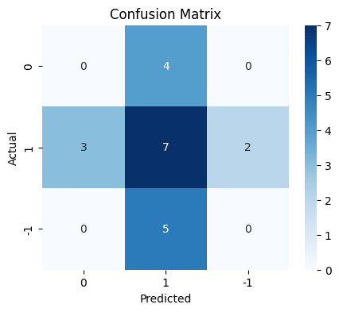

```python
plot_confusion_matrix(base_wv,X_val_wv,y_val)
```

Observations:

There is some imbalance in the classification.

The model is struggling with class 0 since there are no true positives for that class, but it is misclassifying it as class 1 (4 times). This may indicate that class 0 is either underrepresented or difficult to distinguish from class 1 in this dataset.

Class 1 has some misclassifications with 3 false negatives as class 0 and 2 as class -1, indicating that the model might be overly sensitive or unable to clearly differentiate class 1 from the others.

```python
#Calculating different metrics on training data
base_train_wv = model_performance_classification_sklearn(base_wv,X_train_wv,y_train)
print("Training performance:\n", base_train_wv)
```

```
Training performance:
    Accuracy  Recall  Precision   F1
0       1.0     1.0        1.0  1.0
```

```python
#Calculating different metrics on validation data
base_val_wv = model_performance_classification_sklearn(base_wv,X_val_wv,y_val)
print("Validation performance:\n",base_val_wv)
```

```
Validation performance:
    Accuracy    Recall  Precision        F1
0  0.333333  0.333333       0.25  0.285714
```

Observations:

The model is achieving perfect performance on the training set, with all metrics (accuracy, recall, precision, and F1-score) equal to 1.

This suggests that the model is perfectly fitting the training data.

The model's performance on the validation set is significantly lower than on the training set, suggesting poor generalization.

### Base Model - GloVe

```python
#Building the model

#Uncomment only one of the snippets related to fitting the model to the data

#base_wv = GradientBoostingClassifier(random_state = 42)
base_gl = RandomForestClassifier(random_state=42)
#base_wv = DecisionTreeClassifier(random_state=42)

# Fitting on train data
base_gl.fit(X_train_gl, y_train) #Complete the code to fit the chosen model on the train data
```

```
RandomForestClassifier(random_state=42)
```

Observation :

Now, we are training a Random Forest Classifier on the Glove based model

```python
plot_confusion_matrix(base_gl, X_train_gl, y_train) #Complete the code to plot the confusion matrix for the train data
```

[output not shown]

Observation:

True Positives (Diagonal values):

Class 0: 82 instances were correctly classified as 0.

Class 1: 138 instances were correctly classified as 1.

Class -1: 66 instances were correctly classified as -1.

False Positives and False Negatives (Off-diagonal values):

There are no false positives or false negatives. Every prediction has been correct, as evidenced by the zeros in the off-diagonal positions. The model appears to be performing flawlessly on the train data, with no misclassifications at all. This is a positive outcome, but it may raise concerns about overfitting

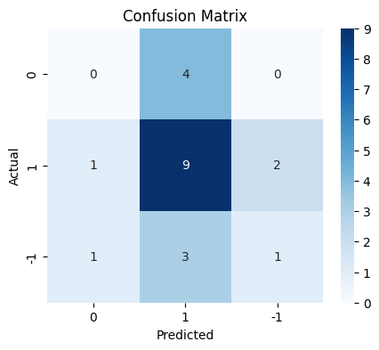

```python
plot_confusion_matrix(base_gl, X_val_gl, y_val)#Complete the code to plot the confusion matrix for the validation data
```

Observation:

The model is struggling with Class 0 as it has zero true positives and misclassifies 4 instances as class 1.

The model's performance on the validation set is not perfect, as there are a number of misclassifications, especially for class 0 where the model shows no true positives.

Model may not be generalizing well.

```python
#Calculating different metrics on training data
base_train_gl = model_performance_classification_sklearn(base_gl, X_train_gl, y_train) #Complete the code to compute the model performance for the training data
print("Training performance:\n", base_train_gl)
```

```
Training performance:
    Accuracy  Recall  Precision   F1
0       1.0     1.0        1.0  1.0
```

```python
#Calculating different metrics on validation data
base_val_gl = model_performance_classification_sklearn(base_gl, X_val_gl, y_val) #Complete the code to compute the model performance for the validation data
print("Validation performance:\n",base_val_gl)
```

```
Validation performance:
    Accuracy   Recall  Precision        F1
0   0.47619  0.47619   0.400794  0.426871
```

Observation:

The model performs perfectly on the training data, achieving perfect scores for all metrics (accuracy, recall, precision, and F1-score). As noted earlier, this can be a sign of overfitting.

The performance on the validation set is considerably lower compared to the training set.

### Base Model - Sentence Transformer

```python
# Building the model

#Uncomment only one of the snippets related to fitting the model to the data

#base_wv = GradientBoostingClassifier(random_state = 42)
#base_wv = RandomForestClassifier(random_state=42)
#base_wv = DecisionTreeClassifier(random_state=42)
base_st = RandomForestClassifier(random_state=42)

# Fitting on train data
base_st.fit(X_train_st, y_train) #Complete the code to fit the chosen model on the train data
```

```
RandomForestClassifier(random_state=42)
```

Observation : Now, we are training a Random Forest Classifier on the Sentence transformer

```python
plot_confusion_matrix(base_st, X_train_st, y_train) #Complete the code to plot the confusion matrix for the train data
```

[output not shown]

Observation:

True Positives (diagonal):

Class 0: 82 instances correctly classified as 0.

Class 1: 138 instances correctly classified as 1.

Class -1: 66 instances correctly classified as -1.

False Positives and False Negatives (off-diagonal):

There are no false positives or false negatives. Every instance has been correctly classified, as shown by the zeros off the diagonal. While perfect classification on the training data is a good sign, it often suggests overfitting,

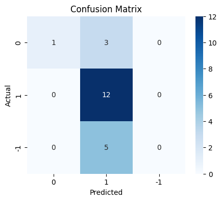

```python
plot_confusion_matrix(base_st, X_val_st, y_val) #Complete the code to plot the confusion matrix for the validation data
```

Observations:

```python
#Calculating different metrics on training data
base_train_st = model_performance_classification_sklearn(base_st, X_train_st, y_train)#Complete the code to compute the model performance for the training data
print("Training performance:\n", base_train_st)
```

```
Training performance:
    Accuracy  Recall  Precision   F1
0       1.0     1.0        1.0  1.0
```

```python
#Calculating different metrics on validation data
base_val_st = model_performance_classification_sklearn(base_st, X_val_st, y_val) #Complete the code to compute the model performance for the validation data
print("Validation performance:\n",base_val_st)
```

```
Validation performance:
    Accuracy    Recall  Precision        F1
0  0.619048  0.619048   0.533333  0.504762
```

Observation:

The model is overfitting on the training data, as indicated by a perfect performance (accuracy, recall, precision, F1-score of 1.0).

The validation performance has significantly dropped compared to the training data.

### Tuned Model - Word2Vec

**Note**: The parameter grid provided below is a sample grid. It can be modified depending on the compute power of the system being used.

```python
start = time.time()

# Choose the type of classifier.

#Uncomment only one of the snippets corrrsponding to the base model trained previously

#tuned_wv = GradientBoostingClassifier(random_state = 42)
tuned_wv = RandomForestClassifier(random_state=42)
#tuned_wv = DecisionTreeClassifier(random_state=42)



parameters = {
    'max_depth': np.arange(3,7),
    'min_samples_split': np.arange(5,12,2),
    'max_features': ['log2', 'sqrt', 0.2, 0.4]
}

# Run the grid search
grid_obj = GridSearchCV(tuned_wv, parameters, scoring='f1_weighted',cv=5,n_jobs=-1)
grid_obj = grid_obj.fit(X_train_wv, y_train)

end = time.time()
print("Time taken ",(end-start))

# Set the clf to the best combination of parameters
tuned_wv = grid_obj.best_estimator_
```

```
Time taken  144.49306058883667
```

```python
# Fit the best algorithm to the data.
tuned_wv.fit(X_train_wv, y_train)
```

```
RandomForestClassifier(max_depth=6, min_samples_split=11, random_state=42)
```

Observation:

This is hyperparameter tuning using GridSearchCV to find the best parameters for the RandomForestClassifier.

We are tuning the following hyperparameters for the RandomForestClassifier:

max_depth: The maximum depth of each tree (values between 3 and 6).

min_samples_split: The minimum number of samples required to split an internal node (values between 5 and 11 with a step of 2).

max_features: The number of features to consider when looking for the best split. You’re testing different values like 'log2', 'sqrt', and fractions (0.2 and 0.4).

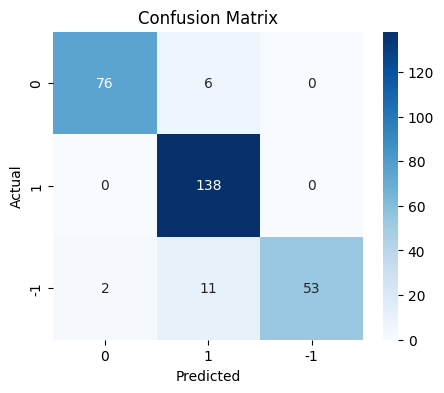

```python
plot_confusion_matrix(tuned_wv,X_train_wv,y_train)
```

Observations:

This is performance of the tuned RandomForestClassifier on the training data. True Positives (Diagonal):

Class 0: 76 instances correctly classified as 0.

Class 1: 138 instances correctly classified as 1.

False Positives and False Negatives (Off-diagonal):

Class 0: 6 instances were misclassified as 1.

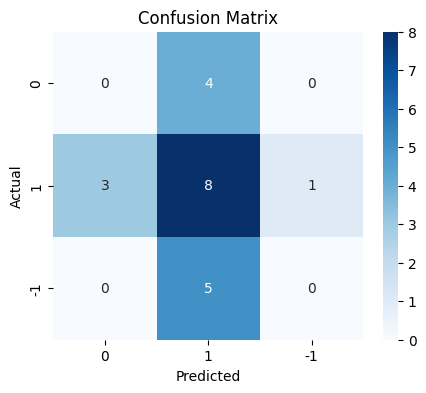

```python
plot_confusion_matrix(tuned_wv,X_val_wv,y_val)
```

Observation:

The confusion matrix for the tuned RandomForestClassifier on the validation data. True Positives (Diagonal values):

Class 1: 8 instances correctly classified as 1.

False Positives and False Negatives (Off-diagonal values):

Class 0: 4 instances incorrectly classified as class 1.

Class 1: 3 instances incorrectly classified as class 0, and 1 instance incorrectly classified as class -1.

Class -1: 0 instances incorrectly classified as class 0. The model seems to have some difficulty distinguishing class 0, as it misclassifies 4 instances as class 1. This indicates some overlap between these two classes.Class 1 is reasonably well classified (8 true positives), but there are still false positives (3 instances incorrectly predicted as class 0) and a small number of false negatives (1 instance predicted as -1).

```python
#Calculating different metrics on training data
tuned_train_wv=model_performance_classification_sklearn(tuned_wv,X_train_wv,y_train)
print("Training performance:\n",tuned_train_wv)
```

```
Training performance:
    Accuracy    Recall  Precision        F1
0  0.933566  0.933566   0.939727  0.932458
```

```python
#Calculating different metrics on validation data
tuned_val_wv = model_performance_classification_sklearn(tuned_wv,X_val_wv,y_val)
print("Validation performance:\n",tuned_val_wv)
```

```
Validation performance:
    Accuracy    Recall  Precision        F1
0  0.380952  0.380952   0.268908  0.315271
```

Observation:

The model performs well on the training set, with high values for accuracy, recall, precision, and F1-score. This suggests that the model is learning the patterns in the training data effectively.

Given that recall and precision are both high and close to each other, it suggests that the model is correctly identifying most positive samples and avoiding false positives.

Accuracy has dropped to 38.1%, which is quite low compared to the training accuracy (93.4%).

Recall and Precision are also much lower, suggesting the model is not generalizing well to the validation data.

### Tuned Model - GloVe

```python
start = time.time()

#Uncomment only one of the snippets corrrsponding to the base model trained previously

#tuned_wv = GradientBoostingClassifier(random_state = 42)
#tuned_wv = RandomForestClassifier(random_state=42)
#tuned_wv = DecisionTreeClassifier(random_state=42)
tuned_gl_model = RandomForestClassifier(random_state=42)

parameters = {
    'max_depth': np.arange(3,7),
    'min_samples_split': np.arange(5,12,2),
    'max_features': ['log2', 'sqrt', 0.2, 0.4]
}

# Run the grid search
grid_obj = GridSearchCV(tuned_gl_model, parameters, scoring='f1_weighted', cv=5, n_jobs=-1) #Complete the code to pass the chosen model
grid_obj = grid_obj.fit(X_train_gl, y_train)

end = time.time()
print("Time taken ",(end-start))

# Set the clf to the best combination of parameters
tuned_gl = grid_obj.best_estimator_
```

```
Time taken  84.29355716705322
```

```python
# Fit the best algorithm to the data.
tuned_gl.fit(X_train_gl, y_train)#Complete the code to fit the chosen model on the train data
```

```
RandomForestClassifier(max_depth=6, max_features=0.2, min_samples_split=7,
                       random_state=42)
```

Observation:

This is hyperparameter tuning using GridSearchCV to find the best parameters for the RandomForestClassifier using training data of glove model. We are tuning the following hyperparameters for the RandomForestClassifier:

max_depth: The maximum depth of each tree (values between 3 and 6).

min_samples_split: The minimum number of samples required to split an internal node (values between 5 and 11 with a step of 2).

max_features: The number of features to consider when looking for the best split. You’re testing different values like 'log2', 'sqrt', and fractions (0.2 and 0.4).

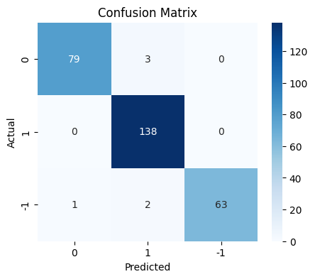

```python
plot_confusion_matrix(tuned_gl, X_train_gl, y_train)#Complete the code to plot the confusion matrix for the train data
```

Observation:

The confusion matrix for the tuned model on training data shows the following: True Positives (Diagonal):

Class 0: 79 instances correctly classified as 0.

Class 1: 138 instances correctly classified as 1.

Class -1: 63 instances correctly classified as -1.

False Positives and False Negatives (Off-diagonal):

Class 0: 3 instances misclassified as 1.

Class -1: 1 instance misclassified as 0, and 2 instances misclassified as 1.

The model is performing reasonably well on the training set, with relatively few misclassifications for each class.Class 0 is classified well, but class -1 appears to be somewhat confused with other classes, especially class 1.

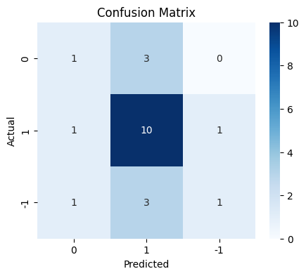

```python
plot_confusion_matrix(tuned_gl, X_val_gl, y_val)#Complete the code to plot the confusion matrix for the validation data
```

Observations:

The confusion matrix for the tuned model on validation data shows the following: True Positives (Diagonal):

Class 1: 10 instances correctly classified as 1.

False Positives and False Negatives (Off-diagonal values):

Class 1: 1 instance misclassified as class 0, and 1 instance misclassified as class -1.

```python
#Calculating different metrics on training data
tuned_train_gl = model_performance_classification_sklearn(tuned_gl, X_train_gl, y_train) #Complete the code to compute the model performance for the training data
print("Training performance:\n",tuned_train_gl)
```

```
Training performance:
    Accuracy    Recall  Precision        F1
0  0.979021  0.979021   0.979545  0.978968
```

```python
#Calculating different metrics on validation data
tuned_val_gl = model_performance_classification_sklearn(tuned_gl, X_val_gl, y_val) #Complete the code to compute the model performance for the validation data
print("Validation performance:\n",tuned_val_gl)
```

```
Validation performance:
    Accuracy    Recall  Precision        F1
0  0.571429  0.571429   0.539683  0.530612
```

Observation:

The model is performing very well on the training set, with high accuracy, recall, precision, and F1-score. This suggests that the model is correctly learning the patterns in the training data

The performance on the validation set is significantly lower compared to the training set The significant difference between training and validation performance suggests overfitting

### Tuned Model - Sentence Transformer

```python
start = time.time()

# Choose the type of classifier.

#Uncomment only one of the snippets corrrsponding to the base model trained previously

#tuned_wv = GradientBoostingClassifier(random_state = 42)
#tuned_wv = RandomForestClassifier(random_state=42)
#tuned_wv = DecisionTreeClassifier(random_state=42)
tuned_st_model = RandomForestClassifier(random_state=42)

parameters = {
    'max_depth': np.arange(3,7),
    'min_samples_split': np.arange(5,12,2),
    'max_features': ['log2', 'sqrt', 0.2, 0.4]
}

# Run the grid search
grid_obj = GridSearchCV(tuned_st_model, parameters, scoring='f1_weighted', cv=5, n_jobs=-1) #Complete the code to pass the chosen model
grid_obj = grid_obj.fit(X_train_st, y_train)

end = time.time()
print("Time taken ",(end-start))

# Set the clf to the best combination of parameters
tuned_st = grid_obj.best_estimator_
```

```
Time taken  165.79925274848938
```

```python
# Fit the best algorithm to the data.
tuned_st.fit(X_train_st, y_train) #Complete the code to fit the chosen model on the train data
```

```
RandomForestClassifier(max_depth=6, max_features=0.2, min_samples_split=11,
                       random_state=42)
```

Observation:

This is hyperparameter tuning using GridSearchCV to find the best parameters for the RandomForestClassifier using training data of Sentence transformer model. We are tuning the following hyperparameters for the RandomForestClassifier:

max_depth: The maximum depth of each tree (values between 3 and 6).

min_samples_split: The minimum number of samples required to split an internal node (values between 5 and 11 with a step of 2).

max_features: The number of features to consider when looking for the best split. You’re testing different values like 'log2', 'sqrt', and fractions (0.2 and 0.4).

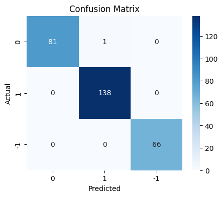

```python
plot_confusion_matrix(tuned_st, X_train_st, y_train) #Complete the code to plot the confusion matrix for the train data
```

Observation:

The confusion matrix for the tuned model on the training data True Positives (Diagonal values):

Class 0: 81 instances correctly classified as 0.

Class 1: 138 instances correctly classified as 1.

Class -1: 66 instances correctly classified as -1.

False Positives and False Negatives (Off-diagonal values):

Class 0: 1 instance misclassified as class 1.

Class 1: 0 instances misclassified as class 0, and 0 misclassified as class -1.

Class -1: 0 instances misclassified as class 0, and 0 misclassified as class 1.

The model performs excellently with very few misclassifications, especially for class 1 and class -1, with only 1 misclassification for class 0 as class 1

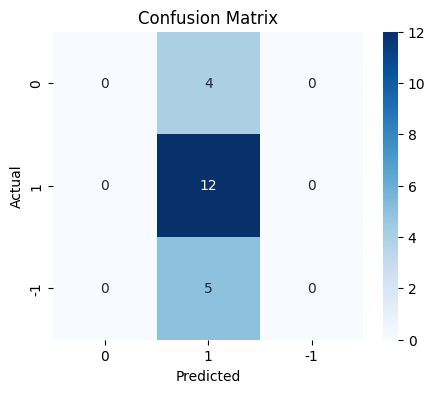

```python
plot_confusion_matrix(tuned_st, X_val_st, y_val) #Complete the code to plot the confusion matrix for the validation data
```

Observations:

The confusion matrix for the tuned model on validation data True Positives (Diagonal values):

Class 1: 12 instances correctly classified as 1.

False Positives and False Negatives (Off-diagonal values):

Class 0: 4 instances misclassified as class 1.

Class 1: 0 instances misclassified as class 0.

Class -1: 0 instances misclassified as class 0.

```python
#Calculating different metrics on training data
tuned_train_st = model_performance_classification_sklearn(tuned_st, X_train_st, y_train)#Complete the code to compute the model performance for the training data
print("Training performance:\n",tuned_train_st)
```

```
Training performance:
    Accuracy    Recall  Precision        F1
0  0.996503  0.996503   0.996529  0.996499
```

```python
#Calculating different metrics on validation data
tuned_val_st = model_performance_classification_sklearn(tuned_st, X_val_st, y_val)#Complete the code to compute the model performance for the validation data
print("Validation performance:\n",tuned_val_st)
```

```
Validation performance:
    Accuracy    Recall  Precision        F1
0  0.571429  0.571429   0.326531  0.415584
```

Observations:

The model performs exceptionally well on the training set, with very high values for accuracy, recall, precision, and F1-score

### Model Performance Summary and Final Model Selection

```python
#training performance comparison

models_train_comp_df = pd.concat(
    [base_train_wv.T,
     base_train_gl.T,
     base_train_st.T,
     tuned_train_wv.T,
     tuned_train_gl.T,
     tuned_train_st.T,
    ],axis=1
)

models_train_comp_df.columns = [
    "Base Model (Word2Vec)",
    "Base Model (GloVe)",
    "Base Model (Sentence Transformer)",
    "Tuned Model (Word2Vec)",
    "Tuned Model (GloVe)",
    "Tuned Model (Sentence Transformer)",
]

print("Training performance comparison:")
models_train_comp_df
```

```
Training performance comparison:
```

|  | Base Model (Word2Vec) | Base Model (GloVe) | Base Model (Sentence Transformer) | Tuned Model (Word2Vec) | Tuned Model (GloVe) | Tuned Model (Sentence Transformer) |
| --- | --- | --- | --- | --- | --- | --- |
| Accuracy | 1.0 | 1.0 | 1.0 | 0.933566 | 0.979021 | 0.996503 |
| Recall | 1.0 | 1.0 | 1.0 | 0.933566 | 0.979021 | 0.996503 |
| Precision | 1.0 | 1.0 | 1.0 | 0.939727 | 0.979545 | 0.996529 |
| F1 | 1.0 | 1.0 | 1.0 | 0.932458 | 0.978968 | 0.996499 |

Observations:

Training Performance Comparison: The table provided compares the training performance of multiple models, including base models (Word2Vec, GloVe, Sentence Transformer) and tuned models (Word2Vec, GloVe, Sentence Transformer).

Accuracy: 0.996503

Precision: 0.996529

Recall: 0.996503

F1-Score: 0.996499

```python
#validation performance comparison

models_val_comp_df = pd.concat(
    [base_val_wv.T,
     base_val_gl.T,
     base_val_st.T,
     tuned_val_wv.T,
     tuned_val_gl.T,
     tuned_val_st.T,
     ],axis=1
)

models_val_comp_df.columns = [
    "Base Model (Word2Vec)",
    "Base Model (GloVe)",
    "Base Model (Sentence Transformer)",
    "Tuned Model (Word2Vec)",
    "Tuned Model (GloVe)",
    "Tuned Model (Sentence Transformer)",
]

print("Validation performance comparison:")
models_val_comp_df
```

```
Validation performance comparison:
```

|  | Base Model (Word2Vec) | Base Model (GloVe) | Base Model (Sentence Transformer) | Tuned Model (Word2Vec) | Tuned Model (GloVe) | Tuned Model (Sentence Transformer) |
| --- | --- | --- | --- | --- | --- | --- |
| Accuracy | 0.333333 | 0.476190 | 0.619048 | 0.380952 | 0.571429 | 0.571429 |
| Recall | 0.333333 | 0.476190 | 0.619048 | 0.380952 | 0.571429 | 0.571429 |
| Precision | 0.250000 | 0.400794 | 0.533333 | 0.268908 | 0.539683 | 0.326531 |
| F1 | 0.285714 | 0.426871 | 0.504762 | 0.315271 | 0.530612 | 0.415584 |

Observations:

Validation Performance Comparison: The table provided compares the validation performance of multiple models, including both base models (Word2Vec, GloVe, Sentence Transformer) and tuned models (Word2Vec, GloVe, Sentence Transformer).

1.The base models (Word2Vec, GloVe, and Sentence Transformer) have low accuracy and precision, particularly for Word2Vec and GloVe.

2.Base Model (Sentence Transformer) performs better than the others with a higher accuracy of 61.9%

3.Tuned models show improvements in most cases, especially Tuned Model (GloVe), which performs much better than the base GloVe model.

### Model Performance Check on Test Data

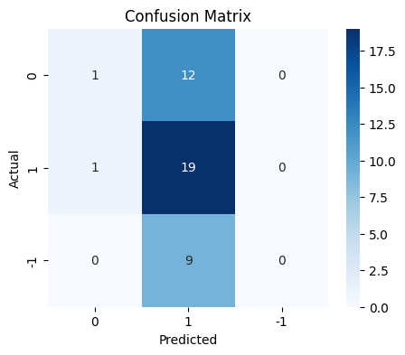

```python
plot_confusion_matrix(tuned_st, X_test_st, y_test) #Complete the code to plot the confusion matrix for the final model and test data
```

Observations:

Lets run test data against the tuned sentence transformer model.The confusion matrix for the tuned model on the test data shows the following.

19 true positives and 1 misclassification as class 0. This suggests the model is performing very well with class 1

```python
#Calculating different metrics on training data
final_model_test = model_performance_classification_sklearn(tuned_st, X_test_st, y_test) #Complete the code to compute the final model's performance for the test data
print("Test performance for the final model:\n",final_model_test)
```

```
Test performance for the final model:
    Accuracy   Recall  Precision        F1
0   0.47619  0.47619   0.380952  0.342857
```

Observation:

The model's accuracy on the test set is about 47.6%, which is relatively low compared to the training data

Given the high performance on the training set and relatively low performance on the test set, the model might be overfitting.

## **Weekly News Summarization**

**Important Note**: It is recommended to run this section of the project independently from the previous sections in order to avoid runtime crashes due to RAM overload.

#### Installing and Importing the necessary libraries

```python
# Installation for GPU llama-cpp-python
# uncomment and run the following code in case GPU is being used
!CMAKE_ARGS="-DLLAMA_CUBLAS=on" FORCE_CMAKE=1 pip install llama-cpp-python==0.1.85 --force-reinstall --no-cache-dir -q

# Installation for CPU llama-cpp-python
# uncomment and run the following code in case GPU is not being used
#!CMAKE_ARGS="-DLLAMA_CUBLAS=off" FORCE_CMAKE=1 pip install llama-cpp-python==0.1.85 --force-reinstall --no-cache-dir -q
```

[output not shown]

```python
# Function to download the model from the Hugging Face model hub
from huggingface_hub import hf_hub_download

# Importing the Llama class from the llama_cpp module
from llama_cpp import Llama

# Importing the library for data manipulation
import pandas as pd

from tqdm import tqdm # For progress bar related functionalities
tqdm.pandas()
```

#### Loading the data

```python
stock_news = pd.read_csv("/content/drive/MyDrive/Stock Market news sentiment analysis/stock_news.csv") #Complete the code to load the dataset
```

```python
data = stock_news.copy()
```

#### Loading the model

```python
model_name_or_path = "TheBloke/Mistral-7B-Instruct-v0.2-GGUF"
model_basename = "mistral-7b-instruct-v0.2.Q6_K.gguf"


model_path = hf_hub_download(
    repo_id="TheBloke/Mistral-7B-Instruct-v0.2-GGUF", # Complete the code to mention the repo_id
    filename=model_basename # Complete the code to mention the filename
)
```

```python
#uncomment the below snippet of code if the runtime is connected to GPU.
llm = Llama(
    model_path=model_path, # Path to the model
    n_gpu_layers=100, #Number of layers transferred to GPU
    n_ctx=4500, #Context window
)
```

```
AVX = 1 | AVX2 = 1 | AVX512 = 0 | AVX512_VBMI = 0 | AVX512_VNNI = 0 | FMA = 1 | NEON = 0 | ARM_FMA = 0 | F16C = 1 | FP16_VA = 0 | WASM_SIMD = 0 | BLAS = 1 | SSE3 = 1 | SSSE3 = 1 | VSX = 0 |
```

```python
# uncomment and run the following code in case GPU is not being used

# llm = Llama(
#     model_path=model_path,
#     n_ctx=4500, # Context window
#     n_cores=-2 # Number of CPU cores to use
# )
```

#### Aggregating the data weekly

```python
data["Date"] = pd.to_datetime(data['Date'])  # Convert the 'Date' column to datetime format.
```

```python
# Group the data by week using the 'Date' column.
weekly_grouped = data.groupby(pd.Grouper(key='Date', freq='W'))
```

```python
# Aggregate the grouped data on a weekly basis:
# concatenate 'content' values into a single string separated by ' || '.
weekly_grouped = weekly_grouped.agg(
    {
        'News': lambda x: ' || '.join(x)  # Join the news values with ' || ' separator.
    }
).reset_index()

print(weekly_grouped.shape)
```

```
(18, 2)
```

Observations:

This is performing weekly aggregation on a dataset, where the "Date" column is used to group the data by week

```python
weekly_grouped
```

|  | Date | News |
| --- | --- | --- |
| 0 | 2019-01-06 | The tech sector experienced a significant dec... |
| 1 | 2019-01-13 | Sprint and Samsung plan to release 5G smartph... |
| 2 | 2019-01-20 | The U.S. stock market declined on Monday as c... |
| 3 | 2019-01-27 | The Swiss National Bank (SNB) governor, Andre... |
| 4 | 2019-02-03 | Caterpillar Inc reported lower-than-expected ... |
| 5 | 2019-02-10 | The Dow Jones Industrial Average, S&P 500, an... |
| 6 | 2019-02-17 | This week, the European Union's second highes... |
| 7 | 2019-02-24 | This news article discusses progress towards ... |
| 8 | 2019-03-03 | The Dow Jones Industrial Average and other ma... |
| 9 | 2019-03-10 | Spotify, the world's largest paid music strea... |
| 10 | 2019-03-17 | The United States opposes France's digital se... |
| 11 | 2019-03-24 | Facebook's stock price dropped more than 3% o... |
| 12 | 2019-03-31 | This news article reports that the S&P 500 In... |
| 13 | 2019-04-07 | Apple and other consumer brands, including LV... |
| 14 | 2019-04-14 | In March, mobile phone shipments to China dro... |
| 15 | 2019-04-21 | The chairman of Taiwan's Foxconn, Terry Gou, ... |
| 16 | 2019-04-28 | Taiwan's export orders continued to decline f... |
| 17 | 2019-05-05 | Spotify reported better-than-expected Q1 reve... |

```python
# creating a copy of the data
data_1 = weekly_grouped.copy()
```

#### Summarization

**Note**:

- The model is expected to summarize the news from the week by identifying the top three positive and negative events that are most likely to impact the price of the stock.
- As an output, the model is expected to return a JSON containing two keys, one for Positive Events and one for Negative Events.

For the project, we need to define the prompt to be fed to the LLM to help it understand the task to perform. The following should be the components of the prompt:

1. **Role**: Specifies the role the LLM will be taking up to perform the specified task, along with any specific details regarding the role
   - **Example**: `You are an expert data analyst specializing in news content analysis.`
2. **Task**: Specifies the task to be performed and outlines what needs to be accomplished, clearly defining the objective
   - **Example**: `Analyze the provided news headline and return the main topics contained within it.`
3. **Instructions**: Provides detailed guidelines on how to perform the task, which includes steps, rules, and criteria to ensure the task is executed correctly
   - **Example**:

```
Instructions:
1. Read the news headline carefully.
2. Identify the main subjects or entities mentioned in the headline.
3. Determine the key events or actions described in the headline.
4. Extract relevant keywords that represent the topics.
5. List the topics in a concise manner.
```

1. **Output Format**: Specifies the format in which the final response should be structured, ensuring consistency and clarity in the generated output
   - **Example**: `Return the output in JSON format with keys as the topic number and values as the actual topic.`

**Full Prompt Example**:

```
You are an expert data analyst specializing in news content analysis.

Task: Analyze the provided news headline and return the main topics contained within it.

Instructions:
1. Read the news headline carefully.
2. Identify the main subjects or entities mentioned in the headline.
3. Determine the key events or actions described in the headline.
4. Extract relevant keywords that represent the topics.
5. List the topics in a concise manner.

Return the output in JSON format with keys as the topic number and values as the actual topic.
```

**Sample Output**:

`{"1": "Politics", "2": "Economy", "3": "Health" }`

Observations:

We are going to generate a process for generating a summary of news headlines that could potentially impact stock prices.

##### Utility Functions

```python
# defining a function to parse the JSON output from the model
def extract_json_data(json_str):
    import json
    try:
        # Find the indices of the opening and closing curly braces
        json_start = json_str.find('{')
        json_end = json_str.rfind('}')

        if json_start != -1 and json_end != -1:
            extracted_category = json_str[json_start:json_end + 1]  # Extract the JSON object
            data_dict = json.loads(extracted_category)
            return data_dict
        else:
            print(f"Warning: JSON object not found in response: {json_str}")
            return {}
    except json.JSONDecodeError as e:
        print(f"Error parsing JSON: {e}")
        return {}
```

Observation:

This code defines a function called extract_json_data, which is designed to parse a JSON-formatted string and return a Python dictionary

##### Defining the response function

```python
#Defining the response function
def response_mistral_1(prompt, news):
    model_output = llm(
      f"""
      [INST]
      {prompt}
      News Articles: {news}
      [/INST]
      """,
      max_tokens=200,      # maximum tokens to generate
      temperature=0.7,       # temperature value
      top_p=0.95,            # top_p value
      top_k=40,              # top_k value
      echo=False,
    )

    final_output = model_output["choices"][0]["text"]

    return final_output
```

Observation:

This function response_mistral_1 seems to interact with a model to generate a response based on a given prompt and news articles

##### Checking the model output on a sample

```python
news = data_1.loc[0, 'News']
```

```python
print(len(news.split(' ')))
news
```

```
2611
```

```
' The tech sector experienced a significant decline in the aftermarket following Apple\'s Q1 revenue warning. Notable suppliers, including Skyworks, Broadcom, Lumentum, Qorvo, and TSMC, saw their stocks drop in response to Apple\'s downward revision of its revenue expectations for the quarter, previ…
```

Observation:

The news article contains 2611 words.This suggests that the article is fairly long,

```python
#Complete the code to define the prompt for this task
prompt = """

You are an expert data analyst specializing in news content analysis.
Task: Analyze the provided weekly news articles and identify the top three positive events and the top three negative events that are most likely to impact the stock price.
Instructions:
1. Read the weekly news articles carefully.
2. Identify key events with positive sentiment and negative sentiment.
3. For positive events, list the top three events; similarly, list the top three negative events.
4. Return the output in JSON format with two keys: "Positive Events" and "Negative Events", each mapping to a list of events.
Example:
{"Positive Events": ["Event1", "Event2", "Event3"], "Negative Events": ["Event1", "Event2", "Event3"]}

"""
```

```python
%%time
summary = response_mistral_1(prompt, news)
print(summary)
```

```
 Title: Apple's Revenue Warning Triggers Global Market Declines: Tech Stocks Drop, Yen Surges, Treasury Yields Fall

       The tech sector experienced a significant decline in the aftermarket following Apple's Q1 revenue warning. Notable suppliers such as Skyworks, Broadcom, Lumentum, Qorvo, TSMC, and Hon Hai Precision Industry saw their stocks drop in response to Apple's downward revision of its revenue expectat…

       Apple lowered its fiscal Q1 revenue guidance from $89-$93 billion to $84 billion due to weaker than expected iPhone sales. The announcement caused a significant drop in Apple's stock price and negatively impacted related suppliers, leading to broader market declines for tech indices such as N…

       Investors sought safety in the highly liquid Japanese y
CPU times: user 18.1 s, sys: 4.94 s, total: 23 s
Wall time: 23.3 s
```

Observations:

The model has likely generated a summarization of the key events from the weekly news that could impact stock prices.

The summarization looks like it correctly identified the impact on the tech sector and the market behavior

##### Checking the model output on the weekly data

```python
%%time
data_1['Key Events'] = data_1['News'].progress_apply(lambda x: response_mistral_1(prompt,x))
```

```
CPU times: user 3min 35s, sys: 32 s, total: 4min 7s
Wall time: 4min 10s
```

Observation:

Model is processing the weekly data using the progress_apply function, which applies the model's response_mistral_1 function to each row of the News column in the data_1 DataFrame.

```python
data_1["Key Events"].head()#Complete the code to print the first 5 rows of the 'Key_Events' column
```

|  | Key Events |
| --- | --- |
| 0 | {"Positive Events": ["Chinese central bank an... |
| 1 | {\n "Positive Events": [\n "S... |
| 2 | {"Positive Events": [\n "Dialog Semic... |
| 3 | {\n "Positive Events": [\n "I... |
| 4 | Based on the provided news articles, here are... |

**dtype:** object

##### Formatting the model output

```python
data_1['model_response_parsed'] = data_1['Key Events'].apply(extract_json_data)
data_1.head()
```

[output not shown]

[output cut: 57 more lines]

[output not shown]

|  | Date | News | Key Events | model_response_parsed |
| --- | --- | --- | --- | --- |
| 0 | 2019-01-06 | The tech sector experienced a significant dec... | {"Positive Events": ["Chinese central bank an... | {'Positive Events': ['Chinese central bank ann... |
| 1 | 2019-01-13 | Sprint and Samsung plan to release 5G smartph... | {\n "Positive Events": [\n "S... | {'Positive Events': ['Sprint and Samsung's pla... |
| 2 | 2019-01-20 | The U.S. stock market declined on Monday as c... | {"Positive Events": [\n "Dialog Semic... | {'Positive Events': ['Dialog Semiconductor rep... |
| 3 | 2019-01-27 | The Swiss National Bank (SNB) governor, Andre... | {\n "Positive Events": [\n "I... | {} |
| 4 | 2019-02-03 | Caterpillar Inc reported lower-than-expected ... | Based on the provided news articles, here are... | {} |

Observation:

For the records that are successfulyy parsed, positive and negative events are extracted.

```python
model_response_parsed = pd.json_normalize(data_1['model_response_parsed'])
model_response_parsed.head()
```

|  | Positive Events | Negative Events |
| --- | --- | --- |
| 0 | [Chinese central bank announces fifth reductio... | [Apple cuts quarterly revenue forecast for the... |
| 1 | [Sprint and Samsung's plan to release 5G smart... | [Geely forecasting flat sales for 2019 due to ... |
| 2 | [Dialog Semiconductor reports revenue in line ... | [U.S. stock market declines due to concerns ov... |
| 3 | NaN | NaN |
| 4 | NaN | NaN |

```python
final_output = pd.concat([data_1.reset_index(drop=True),model_response_parsed],axis=1)
final_output.drop(['Key Events','model_response_parsed'], axis=1, inplace=True)
final_output.columns = ['Week End Date', 'News', 'Week Positive Events', 'Week Negative Events']

final_output.head()
```

|  | Week End Date | News | Week Positive Events | Week Negative Events |
| --- | --- | --- | --- | --- |
| 0 | 2019-01-06 | The tech sector experienced a significant dec... | [Chinese central bank announces fifth reductio... | [Apple cuts quarterly revenue forecast for the... |
| 1 | 2019-01-13 | Sprint and Samsung plan to release 5G smartph... | [Sprint and Samsung's plan to release 5G smart... | [Geely forecasting flat sales for 2019 due to ... |
| 2 | 2019-01-20 | The U.S. stock market declined on Monday as c... | [Dialog Semiconductor reports revenue in line ... | [U.S. stock market declines due to concerns ov... |
| 3 | 2019-01-27 | The Swiss National Bank (SNB) governor, Andre... | NaN | NaN |
| 4 | 2019-02-03 | Caterpillar Inc reported lower-than-expected ... | NaN | NaN |

Observations:

This is the final output DataFrame that concatenates various columns, and then displays the first few rows.

The Week End Date column contains dates representing the end of each week

The News column contains the summary or description of the news event for each week

The Week Positive Events column contains the model's identified positive events for the week

The Week Negative Events column contains the model's identified negative events for the week.

## **Conclusions and Recommendations**

3.Businesses should consider integrating this model with predictive tools to forecast market movements based on weekly news. It would be helpful for the following reasons: a)Pricing strategies

b)Marketing or sales efforts

c)Customer communications

d)Risk Management

The ability to extract and analyze sentiment-driven insights from news data enables businesses to not only understand the current market conditions but also to anticipate future trends.

-